# EDA_Doubs_dataset slides

## 探索式資料分析 統計圖表

#### (參考資料: 吳漢銘教授講義)

#### The Doubs dataset have been collected at 30 sites along the Doubs River (near the France-Switzerland border in the Jura Mountains.)

- DoubsAbu.csv: contains coded abundances of 27 fish species.
- DoubsEnv.csv: contains 11 environmental variables related to the hydrology, geomorphology and chemistry of the river.
- DoubsSpa.csv: contains the geographical coordinates (Cartesian, X and Y) of the sites.

```python
%matplotlib inline
import numpy as np
import pandas as pd
import matplotlib.pyplot as plt
import seaborn as sns
plt.style.use('ggplot')
```

```python
# Take a first look at the dataset
df_Abu = pd.read_csv('DoubsAbu.csv')
print(f'data size: {df_Abu.shape}')
df_Abu.head()
```

```
data size: (30, 27)
```

|  | CHA | TRU | VAI | LOC | OMB | BLA | HOT | TOX | VAN | CHE | ... | ROT | CAR | TAN | BCO | PCH | GRE | GAR | BBO | ABL | ANG |
| --- | --- | --- | --- | --- | --- | --- | --- | --- | --- | --- | --- | --- | --- | --- | --- | --- | --- | --- | --- | --- | --- |
| 0 | 0 | 3 | 0 | 0 | 0 | 0 | 0 | 0 | 0 | 0 | ... | 0 | 0 | 0 | 0 | 0 | 0 | 0 | 0 | 0 | 0.0 |
| 1 | 0 | 5 | 4 | 3 | 0 | 0 | 0 | 0 | 0 | 0 | ... | 0 | 0 | 0 | 0 | 0 | 0 | 0 | 0 | 0 | 0.0 |
| 2 | 0 | 5 | 5 | 5 | 0 | 0 | 0 | 0 | 0 | 0 | ... | 0 | 0 | 0 | 0 | 0 | 0 | 0 | 0 | 0 | 0.0 |
| 3 | 0 | 4 | 5 | 5 | 0 | 0 | 0 | 0 | 0 | 1 | ... | 0 | 0 | 1 | 0 | 0 | 0 | 0 | 0 | 0 | 0.0 |
| 4 | 0 | 2 | 3 | 2 | 0 | 0 | 0 | 0 | 5 | 2 | ... | 2 | 0 | 3 | 0 | 0 | 0 | 5 | 0 | 0 | 0.0 |

5 rows × 27 columns

```python
# Take a first look at the dataset
df_Env = pd.read_csv('DoubsEnv.csv')
print(f'data size: {df_Env.shape}')
df_Env.head()
```

```
data size: (30, 11)
```

|  | das | alt | pen | deb | pH | dur | pho | nit | amm | oxy | dbo |
| --- | --- | --- | --- | --- | --- | --- | --- | --- | --- | --- | --- |
| 0 | 0.3 | 934 | 48.0 | 0.84 | 7.9 | 45 | 0.01 | 0.20 | 0.00 | 12.2 | 2.7 |
| 1 | 2.2 | 932 | 3.0 | 1.00 | 8.0 | 40 | 0.02 | 0.20 | 0.10 | 10.3 | 1.9 |
| 2 | 10.2 | 914 | 3.7 | 1.80 | 8.3 | 52 | 0.05 | 0.22 | 0.05 | 10.5 | 3.5 |
| 3 | 18.5 | 854 | 3.2 | 2.53 | 8.0 | 72 | 0.10 | 0.21 | 0.00 | 11.0 | 1.3 |
| 4 | 21.5 | 849 | 2.3 | 2.64 | 8.1 | 84 | 0.38 | 0.52 | 0.20 | 8.0 | 6.2 |

```python
# Take a first look at the dataset
df_Spa = pd.read_csv('DoubsSpa.csv')
print(f'data size: {df_Spa.shape}')
df_Spa.head()
```

```
data size: (30, 2)
```

|  | x | y |
| --- | --- | --- |
| 0 | 88 | 7 |
| 1 | 94 | 14 |
| 2 | 102 | 18 |
| 3 | 100 | 28 |
| 4 | 106 | 39 |

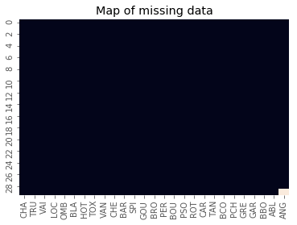

```python
# check missing data
sns.heatmap(df_Abu.isnull(), cbar=False)
plt.title('Map of missing data')
```

```python
# check data types
print(f'Unique data types in the data set: {np.unique(df_Abu.dtypes)}\n')
print(f'Columns in the dataset: {df_Abu.columns}')
```

```
Unique data types in the data set: [dtype('int64') dtype('float64')]

Columns in the dataset: Index(['CHA', 'TRU', 'VAI', 'LOC', 'OMB', 'BLA', 'HOT', 'TOX', 'VAN', 'CHE',
       'BAR', 'SPI', 'GOU', 'BRO', 'PER', 'BOU', 'PSO', 'ROT', 'CAR', 'TAN',
       'BCO', 'PCH', 'GRE', 'GAR', 'BBO', 'ABL', 'ANG'],
      dtype='object')
```

```python
df_Abu.describe()
```

|  | CHA | TRU | VAI | LOC | OMB | BLA | HOT | TOX | VAN | CHE | ... | ROT | CAR | TAN | BCO | PCH | GRE | GAR | BBO | ABL | ANG |
| --- | --- | --- | --- | --- | --- | --- | --- | --- | --- | --- | --- | --- | --- | --- | --- | --- | --- | --- | --- | --- | --- |
| count | 30.000000 | 30.000000 | 30.000000 | 30.000000 | 30.000000 | 30.000000 | 30.000000 | 30.000000 | 30.000000 | 30.000000 | ... | 30.000000 | 30.000000 | 30.000000 | 30.000000 | 30.000000 | 30.000000 | 30.000000 | 30.000000 | 30.000000 | 29.000000 |
| mean | 0.500000 | 1.900000 | 2.266667 | 2.433333 | 0.500000 | 0.633333 | 0.600000 | 0.866667 | 1.433333 | 1.866667 | ... | 0.700000 | 0.833333 | 1.500000 | 0.866667 | 0.600000 | 1.266667 | 2.100000 | 1.033333 | 1.900000 | 0.758621 |
| std | 0.937715 | 2.040115 | 1.981524 | 1.924136 | 1.008584 | 1.299425 | 0.855006 | 1.306043 | 1.501340 | 1.357821 | ... | 1.149213 | 1.341212 | 1.737021 | 1.525266 | 1.302517 | 1.892514 | 2.202663 | 1.711691 | 2.249138 | 1.243703 |
| min | 0.000000 | 0.000000 | 0.000000 | 0.000000 | 0.000000 | 0.000000 | 0.000000 | 0.000000 | 0.000000 | 0.000000 | ... | 0.000000 | 0.000000 | 0.000000 | 0.000000 | 0.000000 | 0.000000 | 0.000000 | 0.000000 | 0.000000 | 0.000000 |
| 25% | 0.000000 | 0.000000 | 0.000000 | 1.000000 | 0.000000 | 0.000000 | 0.000000 | 0.000000 | 0.000000 | 1.000000 | ... | 0.000000 | 0.000000 | 0.000000 | 0.000000 | 0.000000 | 0.000000 | 0.000000 | 0.000000 | 0.000000 | 0.000000 |
| 50% | 0.000000 | 1.000000 | 3.000000 | 2.000000 | 0.000000 | 0.000000 | 0.000000 | 0.000000 | 1.000000 | 2.000000 | ... | 0.000000 | 0.000000 | 1.000000 | 0.000000 | 0.000000 | 0.000000 | 1.000000 | 0.000000 | 0.000000 | 0.000000 |
| 75% | 0.750000 | 3.750000 | 4.000000 | 4.000000 | 0.750000 | 0.750000 | 1.000000 | 2.000000 | 2.000000 | 3.000000 | ... | 1.000000 | 1.000000 | 3.000000 | 1.000000 | 0.000000 | 2.000000 | 5.000000 | 1.750000 | 5.000000 | 1.000000 |
| max | 3.000000 | 5.000000 | 5.000000 | 5.000000 | 4.000000 | 5.000000 | 3.000000 | 4.000000 | 5.000000 | 5.000000 | ... | 5.000000 | 5.000000 | 5.000000 | 5.000000 | 5.000000 | 5.000000 | 5.000000 | 5.000000 | 5.000000 | 4.000000 |

8 rows × 27 columns

#### Overall Distribution of Abundances

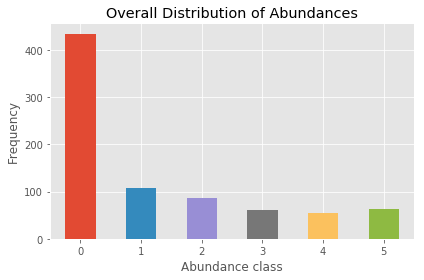

```python
abundance_class = []
for col in df_Abu:
    abundance_class.append(df_Abu[col].value_counts())
abundance_class = pd.DataFrame(abundance_class)

abundance_class.sum(axis=0).plot(kind='bar')

plt.xlabel('Abundance class')
plt.ylabel('Frequency')
plt.xticks(rotation=0)
plt.title('Overall Distribution of Abundances')
plt.tight_layout()
```

#### Species Data: A Closer Look Map of the Locations of the Sites

Question: The river looks more real, but where are the fish?

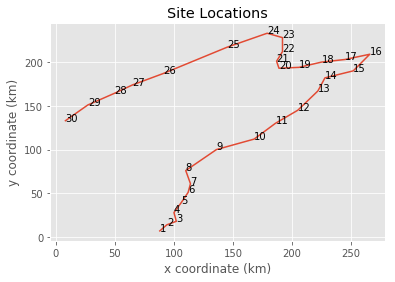

```python
plt.plot(df_Spa['x'], df_Spa['y'])

for i in range(df_Spa.shape[0]):
    plt.annotate(str(i+1), (df_Spa['x'][i], df_Spa['y'][i]))

plt.xlabel('x coordinate (km)')
plt.ylabel('y coordinate (km)')
plt.title('Site Locations')
```

#### Maps of Some Fish Species

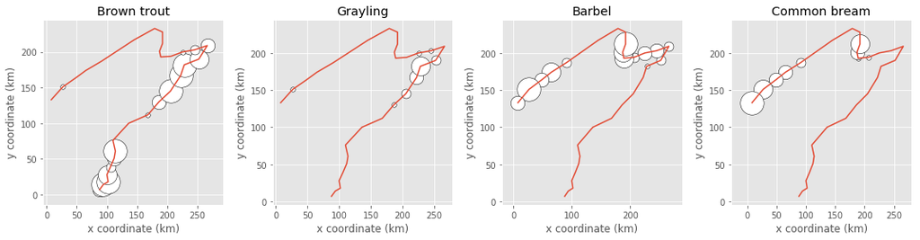

```python
fig, axes = plt.subplots(1, 4, figsize=(15, 4))
cols = ['TRU', 'OMB', 'BAR', 'BCO']
titles = ['Brown trout', 'Grayling', 'Barbel', 'Common bream']

for (ax, col, title) in zip(axes.ravel(), cols, titles):
    ax.plot(df_Spa['x'], df_Spa['y'])
    for i in range(df_Abu.shape[0]):
        ax.scatter(df_Spa['x'][i], df_Spa['y'][i], marker='o', s=np.square(df_Abu.iloc[i][col])*30, facecolor='w', edgecolor='k')
    ax.set_xlabel('x coordinate (km)')
    ax.set_ylabel('y coordinate (km)')
    ax.set_title(title)
plt.tight_layout()
```

#### Compare Species: Number of Occurrences

At how many sites does each species occur? Calculate the relative frequencies of species (proportion of the number of sites) and plot histograms.

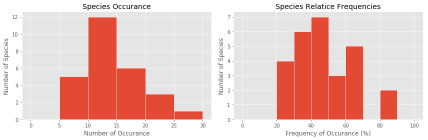

```python
fig, axes = plt.subplots(1, 2, figsize=(12, 4))
axes = axes.ravel()

species_occurance = (df_Abu > 0).astype(int).sum(axis=0).sort_values()
species_occurance.plot(kind='hist', bins=np.linspace(0, 30, 7), edgecolor='w', ax=axes[0])
axes[0].set_xlabel('Number of Occurance')
axes[0].set_ylabel('Number of Species')
axes[0].set_title('Species Occurance')

species_occurance = species_occurance / 30 * 100
species_occurance.plot(kind='hist', bins=np.linspace(0, 100, 11), edgecolor='w', ax=axes[1])
axes[1].set_xlabel('Frequency of Occurance (%)')
axes[1].set_ylabel('Number of Species')
axes[1].set_title('Species Relatice Frequencies')
plt.tight_layout()
```

#### Compare Sites: Species Richness

Now that we have seen at how many sites each species is present, we may want to know how many species are present at each site (species richness).

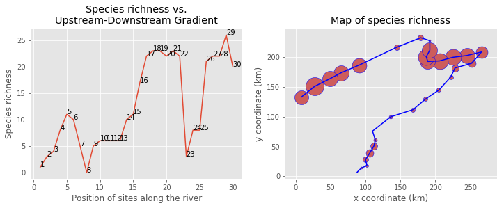

```python
fig, axes = plt.subplots(1, 2, figsize=(12, 4))
axes = axes.ravel()
species_richness = (df_Abu > 0).astype(int).sum(axis=1)
axes[0].plot(np.arange(1, df_Abu.shape[0]+1), species_richness)
for i in range(df_Spa.shape[0]):
    axes[0].annotate(str(i+1), (i+1, species_richness[i]))
axes[0].set_xlabel('Position of sites along the river')
axes[0].set_ylabel('Species richness')
axes[0].set_title('Species richness vs.\nUpstream-Downstream Gradient')
axes[1].plot(df_Spa['x'], df_Spa['y'], c='b')
for i in range(df_Spa.shape[0]):
    axes[1].scatter(df_Spa['x'][i], df_Spa['y'][i], marker='o', s=np.square(species_richness[i]), c='indianred', edgecolor='b')
axes[1].set_xlabel('x coordinate (km)')
axes[1].set_ylabel('y coordinate (km)')
axes[1].set_title('Map of species richness')
```

#### Boxplots of Transformed Abundances of a Common Species

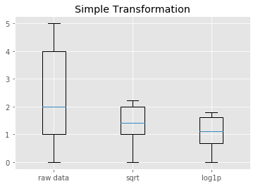

```python
plt.boxplot([df_Abu['LOC'], np.sqrt(df_Abu['LOC']), np.log(df_Abu['LOC'] + 1)])
plt.xticks(np.arange(1, 4), ['raw data', 'sqrt', 'log1p'])
plt.title('Simple Transformation')
```

#### Bubble Maps of Some Environmental Variables

- Which ones of these maps display an upstream-downstream gradient?
- How could you explain the spatial patterns of the other variables?

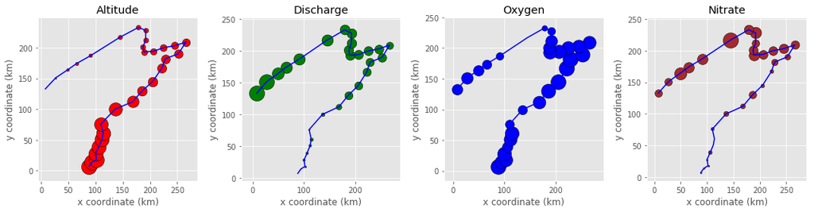

```python
fig, axes = plt.subplots(1, 4, figsize=(15, 4))
axes = axes.ravel()
cols = ['alt', 'deb', 'oxy', 'nit']
colors = ['red', 'green', 'blue', 'brown']
titles = ['Altitude', 'Discharge', 'Oxygen', 'Nitrate']

marker_size = df_Env.copy()
for col in df_Env:
    Vmin = df_Env[col].min()
    Vmax = df_Env[col].max()
    marker_size[col] = (df_Env[col] - Vmin) / (Vmax - Vmin)

for (col, title, color, ax) in zip(cols, titles, colors, axes):
    ax.plot(df_Spa['x'], df_Spa['y'], c='b')
    for i in range(df_Spa.shape[0]):
        ax.scatter(df_Spa['x'][i], df_Spa['y'][i], marker='o', s=marker_size[col][i] * 400, c=color, edgecolor='k')
        ax.set_xlabel('x coordinate (km)')
        ax.set_ylabel('y coordinate (km)')
        ax.set_title(title)

plt.tight_layout()
plt.savefig('env.png')
```

#### Examine the Variation of Some Descriptors Along the Stream: Line Plots

(Note the scalings.)

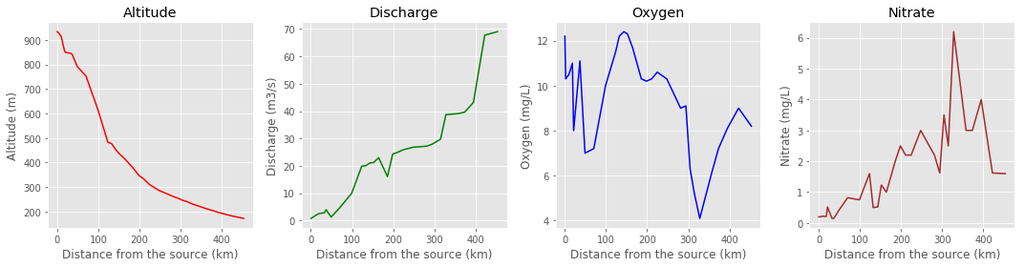

```python
fig, axes = plt.subplots(1, 4, figsize=(15, 4))
axes = axes.ravel()
cols = ['alt', 'deb', 'oxy', 'nit']
colors = ['red', 'green', 'blue', 'brown']
ylabels = ['Altitude (m)', 'Discharge (m3/s)', 'Oxygen (mg/L)', 'Nitrate (mg/L)']
titles = ['Altitude', 'Discharge', 'Oxygen', 'Nitrate']

for (col, title, ylabel, color, ax) in zip(cols, titles, ylabels, colors, axes):
    ax.plot(df_Env['das'], df_Env[col], c=color)
    ax.set_xlabel('Distance from the source (km)')
    ax.set_ylabel(ylabel)
    ax.set_title(title)

plt.tight_layout()
```

#### Scatter Plots for All Pairs of Environmental Variables

- Do many variables seem normally distributed?
- Do many scatter plots show linear or at least monotonic relationships?

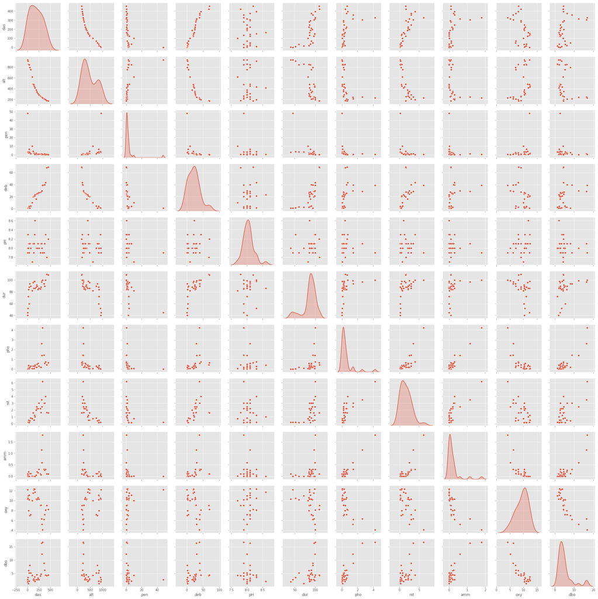

```python
sns.pairplot(df_Env, diag_kind='kde')
```

#### Simple Transformation of An Environmental Variable

- Simple transformations, such as the log transformation, can be used to improve the distributions of some variables (make it closer to the normal distribution).
- Because environmental variables are dimensionally heterogeneous (expressed in different units and scales), many statistical analyses require their standardization to zero mean and unit variance. These centred and scaled variables are called z-scores.

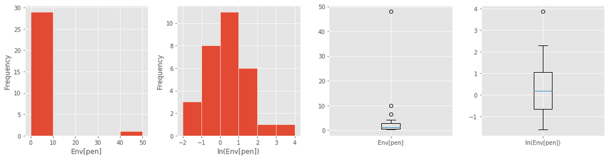

```python
#河道坡度
fig, axes = plt.subplots(1, 4, figsize=(15, 4))
axes = axes.ravel()

axes[0].hist(df_Env['pen'], bins=np.linspace(0, 50, 6), edgecolor='w')
axes[0].set_xlabel('Env[pen]')
axes[0].set_ylabel('Frequency')

axes[1].hist(np.log(df_Env['pen']), bins=np.linspace(-2, 4, 7), edgecolor='w')
axes[1].set_xlabel('ln(Env[pen])')
axes[1].set_ylabel('Frequency')

axes[2].boxplot(df_Env['pen'])
axes[2].set_xticklabels(['Env[pen]'])

axes[3].boxplot(np.log(df_Env['pen']))
axes[3].set_xticklabels(['ln(Env[pen])'])

plt.tight_layout()
```